# Generating raw-to-norm-score lookup tables with cNORM

#### Overview

This demonstration uses the `cNORM` package to fit a norming model to a set of raw scores, and to generate raw-to-norm-score[^1] lookup tables based on the model. `cNORM` employs a regression-based modeling process, which uses the variance of the entire normative sample to correct for age-specific distributional anomalies and sampling error. For more technical background on `cNORM`, please see Appendix A.

The demonstration data is from the Tests of Dyslexia (TOD) project (2021). The input file contains data from the TOD-Comprehensive (TOD-C) standardization study, with 1407 cases ranging in age from 6 to 19. The file contains raw scores from three TOD subtests (Irregular Word Spelling (`iws`), Blending (`bln`), and Segmenting (`seg`), as well as date of birth (`DOB`), date of testing (`admin_date`), grade level (`GradeSemester`), and other demographic variables.

The script proceeds through data preparation, modeling, and output stages. The output comprises raw-to-norm-score lookup tables, in both single-table and tabbed format; a reversal report that flags anomalous age-related changes in norm scores; and a model summary that facilitates replication of the analysis.

This demonstration produces age-based norms. Grade-based norms require slight modifications to the script, as detailed in Appendix B.

To run this demonstration, set up an RStudio project called `cNORM`, with subfolders `CODE`, `INPUT-FILES` and `OUTPUT-FILES`. Save scripts in `CODE`, and run them from within the `cNORM` project.

#### Executable Code

```r
suppressMessages(library(cNORM))
suppressMessages(suppressWarnings(library(tidyverse)))
suppressMessages(library(here))
library(writexl)
suppressMessages(library(lubridate))

urlRemote_path  <- "https://raw.github.com/"
github_path <- "wpspublish-public/DSHerzberg-cNORM/master/INPUT-FILES/"
data_file_name <- "cNORM-demo-TOD-input-data.csv"

input_original <- suppressMessages(read_csv(url(
  str_c(urlRemote_path, github_path, data_file_name)
)))

scores <- c("iws_sum", "bln_sum", "seg_sum")
score_to_norm_stem <- "iws_sum"
score_to_norm_file_name <- str_c(score_to_norm_stem, "-norms-input.csv")
score_to_norm_max_raw <- data.frame(test = score_to_norm_stem) %>%
  mutate(max_raw = case_when(
    str_detect(test, "iws_sum") ~ 44,
    str_detect(test, "bln_sum") ~ 29,
    str_detect(test, "seg_sum") ~ 29
  )) %>%
  pull(max_raw)

age_contin <- input_original %>%
  mutate(across(c(DOB, admin_date),
                ~
                  mdy(.x)),
         age = (DOB %--% admin_date) / years (1)) %>%
  bind_cols(getGroups(.$age)) %>%
  rename(group = ...14) %>%
  select(ID, age, group)

map(
  scores,
  ~
    input_original %>%
    select(ID,!!sym(.x)) %>%
    drop_na(!!sym(.x)) %>%
    left_join(age_contin, by = "ID") %>%
    rename(raw = !!sym(.x)) %>%
    select(ID, age, group, raw)
) %>%
  set_names(scores) %>%
  map2(scores,
       ~
         write_csv(.x,
                   here(
                     str_c("OUTPUT-FILES/", .y, "-norms-input.csv")
                   ))) %>%
  invisible(.)

input <- suppressMessages(read_csv(here(
  str_c("OUTPUT-FILES/", score_to_norm_file_name)
)))

model <- cnorm(
  raw = input$raw,
  group = input$group,
  terms = 4,
  scale = "IQ"
)

plot(model, "series", end = 8)
checkConsistency(model)

tab_names <- c(
  "6.0-6.3",
  "6.4-6.7",
  "6.8-6.11",
  "7.0-7.3",
  "7.4-7.7",
  "7.8-7.11",
  "8.0-8.5",
  "8.6-8.11",
  "9.0-9.5",
  "9.6-9.11",
  "10.0-10.5",
  "10.6-10.11",
  "11.0-11.5",
  "11.6-11.11",
  "12.0-12.5",
  "12.6-12.11",
  "13.0-13.11",
  "14.0-14.11",
  "15.0-16.11",
  "17.0-18.11"
)

norms_list <- rawTable(
  c(
    6.167,
    6.5,
    6.833,
    7.167,
    7.5,
    7.833,
    8.25,
    8.75,
    9.25,
    9.75,
    10.25,
    10.75,
    11.25,
    11.75,
    12.25,
    12.75,
    13.5,
    14.5,
    16,
    18.0
  ),
  model,
  step = 1,
  minNorm = 40,
  maxNorm = 130,
  minRaw = 1,
  maxRaw = score_to_norm_max_raw,
  pretty = FALSE
) %>%
  set_names(tab_names) %>%
  map(~
        select(.x, raw, norm) %>%
        summarize(raw = raw,
                  ss = round(norm, 0)))

reversal_report <- norms_list %>%
  reduce(left_join,
         by = "raw") %>%
  set_names("raw", tab_names) %>%
  pivot_longer(-raw, names_to = "agestrat", values_to = "ss") %>%
  group_by(raw) %>%
  mutate(reversal = case_when(lag(ss) < ss ~ 1)) %>%
  filter(reversal == 1) %>%
  select(raw, agestrat) %>%
  write_csv(here(
    str_c("OUTPUT-FILES/", score_to_norm_stem, "-reversal-report-age.csv")
  ))

write_xlsx(norms_list,
           here(
             str_c(
               "OUTPUT-FILES/",
               score_to_norm_stem,
               "-raw-ss-lookup-tabbed-age.xlsx"
             )
           ))

table <- norms_list %>%
  reduce(left_join,
         by = "raw") %>%
  set_names("raw", tab_names)

write_csv(table,
          here(
  str_c("OUTPUT-FILES/", score_to_norm_stem, "-raw-ss-lookup-table-age.csv")
))

capture.output(
  str_c(score_to_norm_stem, " model summary"),
  summary(model),
  file = here(
    str_c("OUTPUT-FILES/", score_to_norm_stem, "-model-summ-age.txt")  )
)
```

#### Commented Snippets

##### 1. Data Preparation

Load packages for norming (`cNORM`), data wrangling (`tidyverse`), file path specification (`here`), writing .xlsx output (`writexl`), and working with data/time data (`lubridate`). Specifiy file path tokens. `read_csv()` the input data set into `input_original`, using `url()` to retrieve data from a remote website. Use `str_c()` to concatenate the file path tokens into a single file path.

```r
suppressMessages(library(cNORM))
suppressMessages(suppressWarnings(library(tidyverse)))
suppressMessages(library(here))
library(writexl)
suppressMessages(library(lubridate))

urlRemote_path  <- "https://raw.github.com/"
github_path <- "wpspublish-public/DSHerzberg-cNORM/master/INPUT-FILES/"
data_file_name <- "cNORM-demo-TOD-input-data.csv"

input_original <- suppressMessages(read_csv(url(
  str_c(urlRemote_path, github_path, data_file_name)
)))
```

Specify score related tokens. `score_to_norm_max_raw` is a numerical vector containing the maximum possible raw score for `score_to_norm_stem` (the score being normed).

To generate `score_to_norm_max_raw`, start by using `data.frame(test = score_to_norm_stem)` to initialize a single-cell data frame, with the `test` column holding the name of the score to be normed. Use `mutate()` to create a second column (`max_raw`) containing the maximum value for that score.

Use `case_when()` to code `max_raw` conditionally, based on the value of `test`. For example, `str_detect(test, "iws_sum")` returns `TRUE` when the value of `test` contains the string `"iws_sum"`. Under that condition, `case_when()` sets the value of `max_raw` to `44`.

`mutate()` returns a two-column data frame. Use `pull()` to extract the value of `max_raw` into the vector `score_to_norm_max_raw`.

```r
score_to_norm_stem <- "iws_sum"
score_to_norm_file_name <- str_c(score_to_norm_stem, "-norms-input.csv")
score_to_norm_max_raw <- data.frame(test = score_to_norm_stem) %>%
  mutate(max_raw = case_when(
    str_detect(test, "iws_sum") ~ 44,
    str_detect(test, "bln_sum") ~ 29,
    str_detect(test, "seg_sum") ~ 29
  )) %>%
  pull(max_raw)
```

A useful feature of `cNORM` is its capacity to implement optimized age stratification, constructing age groups that are best suited to the modeling of age-related score changes, based on the characteristics of a particular input data set. Often, *a priori* age groups, which serve the needs of the users of published norms, do not parition the input sample in the way that best supports the `cNORM` modeling functions. After `cNORM` generates a norming model based on optimized age-stratification, the operator can specify a different age-stratification scheme for the raw-to-norm-score lookup tables. Thus it is possible to recreate the *a priori* age groups in the final output of `cNORM`, to support clinical application of the published norms tables.

We invoke `cNORM`’s age-stratification function by calling `cNORM::getGroups()`, which creates a new data frame (which we name `age_contin`) to hold a continuous age variable (in decimal format) for each case in the input file. We use `mutate(across())` and `lubridate::mdy()` to coerce the date variables (`DOB`, `admin_date`), which are strings in the input file, into a numeric date-time format. Within `mdy()`, the `.x` token represents the variables designated for transformation by `across()`.

Within the same call of `mutate()`, we calculate a new decimal-format `age` variable. The `%--%` operator of `lubridate` creates an arithmetic date-time interval, or duration, between a start date (here `DOB`) and an end date (here `admin_date`). Dividing this interval, which represents chronological age, by a time period (here `years(1)`, which returns 1 year as an arithmetic date-time period), converts chronological age expressed as years-months-days (e.g., 5 years, 6 months, 0 days) in to a decimal-format age value (e.g., 5.5).

By specifying `getGroups(.$age)` we enable `getGroups()` to operate on the new `age` column of the current data object.

By default, `getGroups()` attempts to form equal-sized age groups with about 100 cases each. Below are the labels for the 15 age groups that `getGroups()` created from the input sample, which has 1407 cases. Each label is the arithmetic mean of the `age` variable for the cases assigned to that group.

```
6.964081
8.016325
8.612022
9.113898
9.694660
10.378862
11.024620
11.689430
12.409892
13.102322
13.851553
14.827028
15.693530
16.688863
17.971970
```

Wrapping `getGroups()` in `bind_cols()` adds a new column to the input data object. This new column, which is provisionally named `...14` for its position in the current data object, contains the age-group assignment for each case in the input sample. We complete the setup of the `age_contin` data frame by renaming `...14` to the more meaningful `group`, and keeping only required columns with `select()`.

```r
age_contin <- input_original %>%
  mutate(across(c(DOB, admin_date),
                ~
                  mdy(.x)),
         age = (DOB %--% admin_date) / years (1)) %>%
  bind_cols(getGroups(.$age)) %>%
  rename(group = ...14) %>%
  select(ID, age, group)
```

The `cNORM` modeling functions operate on one raw score at a time. For tests with multiple subtest scores, therefore, we can run this entire script repeatedly, processing one score at a time. The next code block partitions the input data file, which contains three subtest raw scores for each case, into separate data frames for each score. These data frames contain only the variables needed by `cNORM`.

The code includes two iterative segments. In the first, `map()` is used to apply a series of functions to each element of the `scores` vector, which contains the names of the three subtest scores in the input data set. Within `map`, `.x` represents the currently-iterated element of the `scores` vector (i.e., the name of a subtest score).

In the function pipeline, `input_original` is sent to `select` to subset only the columns required by `cNORM`, which are the case `ID` and the subtest score to be normed. Because the vector `scores` contains quoted strings, and `select()` expects unquoted column names, `!!sym(.x)` is used to unquote the currently iterated subtest name. This same unquoting function is used elsewhere in this pipeline.

`drop_na()` deletes rows (cases) that are missing the subtest score currently being normed. `left_join()` joins the columns of the current object with those of the previously created `age_contin` data frame, matching cases `by = "ID"`. To obtain the column configuration required by `cNORM`, `rename()` changes the subtest score name to the generic `raw`, and `select(ID, age, group, raw)` subsets the columns in the preferred left-right sequence.

At this point, `map()` finishes iterating and returns a list of unnamed data frames, one for each subtest score, containing the variables required by `cNORM`. `set_names(scores)` is used to name each data frame with its corresponding subtest label.

Next, the list of data frames is piped into `map2()`, which enables simultaneous parallel iteration over two inputs of equal length (tokenized as `.x` and `.y`). In this call of `map2()`, the current piped object (the list of data frames) is the `.x` input, and the `scores` vector is the `.y` input. Both inputs have three elements (i.e., they are of equal length).

The purpose of the `map2()` call is to write each of the data frames on the input list to an external `.csv` file, where it can then be read back in for processing by `cNORM`. `write_csv()` is used to write the currently iterated `.x` data frame to a file path/file name that includes that currently iterated `.y` subtest score name. `here()` anchors the file path in the `cNORM` project folder, and `str_c()` concatenates three string elements, including the `.y` name, into a new string that is the file path.

Because the script writes external files, there’s no need to preserve the list of subtest-specific data frames in the global environment. The last function in the pipeline, `invisible(.)`, ensures that the list object neither prints to the console nor appears in the global environment. Here, as elsewhere in the code, `.` is a token designating the current data object in the pipeline.

```r
map(
  scores,
  ~
    input_original %>%
    select(ID,!!sym(.x)) %>%
    drop_na(!!sym(.x)) %>%
    left_join(age_contin, by = "ID") %>%
    rename(raw = !!sym(.x)) %>%
    select(ID, age, group, raw)
) %>%
  set_names(scores) %>%
  map2(scores,
       ~
         write_csv(.x,
                   here(
                     str_c("OUTPUT-FILES/", .y, "-norms-input.csv")
                   ))) %>%
  invisible(.)
```

##### 2. Modeling

The next code block executes the `cNORM` modeling process, in which age-related development of a latent ability is modeled using raw scores from a normative sample[^2]. This model of development is eventually operationalized as a set of raw-to-norm score lookup tables.

As noted previously, `cNORM` processes one raw score at a time. Here, `read_csv()` is used to read in one of the single-score data frames written out by upstream code. The resulting object is named `input`. The file path is concatenated from previously initialized tokens. In the present example, `iws_sum` is the raw score to be normed.

`cnorm()` is the modeling function, and its arguments[^3] are as follows:

- `raw`: designates the raw score column in the input data file (here `input$raw`).
- `group`: designates the age group column in the input data file (here `input$group`).
- `terms`: sets the number of terms in the regression equation that expresses the normative model. `cnorm()` finds the best-fitting model with this number of terms. By convention, we use a starting value of 4 for `terms`.
- `scale`: sets the metric of the norm score. Values can be `"IQ"`,`"T"`,`"z"`, `"percentile"`, or a vector that provides the mean and standard deviation of the preferred metric (e.g., `c(10, 3)`).

```r
input <- suppressMessages(read_csv(here(
  str_c("OUTPUT-FILES/", score_to_norm_file_name)
)))

model <- cnorm(
  raw = input$raw,
  group = input$group,
  terms = 4,
  scale = "IQ"
)
```

The initial output of `cnorm()` is a model summary printed in the console, and a plot of the observed and predicted percentile curves associated with the norming model. The plot shown below is for the `iws` raw score in the input sample.

At this point, the norming workflow extends outside the mere sequential execution of this script. The initial model is evaluated, using diagnostic tools available within `cNORM`. If this initial model is judged acceptable, the output phase of the norms process can proceed. However, if the initial model is problematic, we re-run the `cnorm()` function with different values of `terms`, and examine these subsequent models with the diagnostic aids, repeating the process until we settle on a model that is acceptable (or, at least, the model with the fewest observable flaws).

*Monotonicity* is the primary criterion for evaluating the normative model. When we test a developing cognitive ability, the expectation is that raw scores will increase monotonically (that is, increase without ever decreasing) with increasing age. Consequently, we expect that a specific raw score will be associated with progressively lower norm scores as age increases. This occurs because the mean raw score increases from one age group to the next, and, as a result, an identical raw score moves to a lower rank in the next oldest age group, and so on.

The best way to check monotonicity after running `cnorm()` is to examine the plot of percentile curves associated with the model. In this plot, the *x*-axis variable is age group, and the *y*-axis variable is raw score. The plot illustrates seven percentile ranks: 2.5, 10, 25, 50, 75, 90, 97.5. The colored circles represent the actual raw scores associated with these percentiles, per age group, in the input data. The solid lines represent the outcome of the modeling process, whereby the selected regression equation is used to smooth the age-related progression of each percentile rank.

If those curves *do not* intersect (as in the example below), the model exhibits adequate monotonicity, and we can proceed to the output phase. If, on the other hand, the percentile curves *do* intersect, it indicates an unexpected change in the raw to norm-score relationship from one age group to the next (i.e., an absence of monotonicity). For example, the plot may reveal that certain raw scores are associated with *higher* norm scores in the next oldest age group. This counter-intuitive outcome is referred to as a norm-score *reversal*.

The plot also shows the proportion of variance in raw scores that is explained by the regression model (here, R<sup>2</sup> = 0.9677). This value is often quite large, even in models that lack monotonicity, because violations of monotonicity almost always occur in the tails of the modeled score distribution, and thus have relatively little influence on R<sup>2</sup>, which expresses the total amount of variance explained by the model. For our purposes, R<sup>2</sup> is less important than monotonicity in terms of evaluating the adequacy of the model.

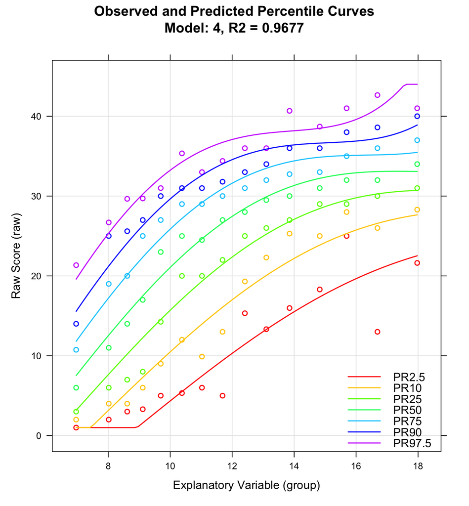

When the plot shows intersecting percentile curves, we re-run the `cnorm()` modeling function with different values of `terms`, in order to find a model that yields non-intersecting curves (if such a model exists). To examine alternative models, we use another diagnostic tool: `plot(model, "series", end = 8)`. This call of `plot()` returns a series of percentile graphs for `terms = 1` through `terms = 8`. Often, varying the number of regression terms will result in a plot with non-intersecting curves.

In general, parsimony applies: it’s best to select a model with fewer terms, all else being equal. Increasing the number of terms increases the risk of *overfitting* the model (that is, modeling error in addition to the developmental gradient of the latent ability). In the percentile plot, an overfitted model is visualized in curves that twist and turn sharply around the raw score data points (colored circles). In contrast, a properly fitted model will yield smoothly increasing parallel colored lines.

A further diagnostic aid is `checkConsistency(model)`, which offers a programmatic check on monotonicity. When `checkConsistency()` returns `FALSE`, it indicates that the norming model is adequately specified, with no violations of monotonicity. If `checkConsistency()` finds problems with the model, it returns the ages at which violations of monotonicity are identified. These findings can be checked against the model plot. In addition, we can generate raw-to-norm score lookup tables based on a problematic model, to see where score reversals occur.

A final note about model specification is that with some data sets, it may not be possible to find a norming model that is completely free of violations of monotonicity. Finalizing the norms then becomes a process of selecting the least-flawed model, and then manually correcting score reversals and other anomalies in the resulting raw-to-norm-score lookup tables.

```r
plot(model, "series", end = 8)
checkConsistency(model)
```

##### 3. Output

The final section of this script prepares the four output elements described earlier: raw-to-norm score lookup tables, in both single-table and tabbed format; a reversal report that flags anomalous age-related changes in standard scores; and a model summary that facilitates replication of the analysis.

`rawTable()` is the `cNORM` function that generates raw-to-norm-score lookup tables. As noted previously, the age stratification scheme for the lookup tables need not be the same one that was used for normative modeling. To specify a new age stratification for output, we first create a character vector (`tab_names`) holding text labels for the age groups. Here, the the labels provide the upper- and lower- bounds of each age group, expressed in “year.month” format (e.g, `"6.0-6.3"`). We use these strings as tab labels for one component of output: a tabbed, .xlsx workbook, with one tab per age group. In this character vector, the particular labeling format is arbitrary (e.g., “6 years, 0 months to 6 years, 3 months” would also work).

```r
tab_names <- c(
  "6.0-6.3",
  "6.4-6.7",
  "6.8-6.11",
  "7.0-7.3",
  "7.4-7.7",
  "7.8-7.11",
  "8.0-8.5",
  "8.6-8.11",
  "9.0-9.5",
  "9.6-9.11",
  "10.0-10.5",
  "10.6-10.11",
  "11.0-11.5",
  "11.6-11.11",
  "12.0-12.5",
  "12.6-12.11",
  "13.0-13.11",
  "14.0-14.11",
  "15.0-16.11",
  "17.0-18.11"
)
```

Next, we re-specify this age stratification scheme as a numerical vector, which we pass as the first argument to `rawTable()`. Here, each age group is expressed as a decimal age value: the mid-point of the age range defined by the group’s corresponding text label. For example, `6.167` expresses the mid-point of the age range defined by `"6.0-6.3"`.

```r
norms_list <- rawTable(
  c(
    6.167,
    6.5,
    6.833,
    7.167,
    7.5,
    7.833,
    8.25,
    8.75,
    9.25,
    9.75,
    10.25,
    10.75,
    11.25,
    11.75,
    12.25,
    12.75,
    13.5,
    14.5,
    16,
    18.0
  ),
```

The remaining arguments to `rawTable()`are:

- `model`: the norming model created previously by `cnorm()`.
- `step`: the raw-score increment for the lookup tables (usually set to `1`).
- `minNorm`, `maxNorm`: the lower and upper bounds, respectively of the the range of *norm scores* that can be looked up in the output tables.
- `minRaw`, `maxRaw`: the lower and upper bounds, respectively of the range of *raw scores* that can be looked up in the output tables (here, `maxRaw` is set to `score_to_norm_max_raw`, a token defined in upstream code).
- `pretty`: a table-formatting command (here, it is set to `FALSE` so that we can impose custom formatting on the output tables) .

```r
  model,
  step = 1,
  minNorm = 40,
  maxNorm = 130,
  minRaw = 1,
  maxRaw = score_to_norm_max_raw,
  pretty = FALSE
) %>%
```

When `rawTable()` is used in this manner to create lookup tables for multiple age groups, it returns a list of data frames, constituting one lookup table for each age group. We pipe this list into `set_names()` to name each date frame with the corresponding age-range label from the `tab_names` vector.

We then `map()` several functions over each of the data frames, to apply formatting elements. We call `select(.x, raw, norm)` so that from each data frame (denoted within the `map()` call by the `.x` token), we retain only the `raw` and `norm` columns. This modified element is then passed to `summarize()`, which keeps `raw` in its current numerical format, while rounding and renaming `norm` (to `ss`, an acronym for the IQ-type standard score).

```r
  set_names(tab_names) %>%
  map(~
        select(.x, raw, norm) %>%
        summarize(raw = raw,
                  ss = round(norm, 0)))
```

Here is an example of a lookup table with this formatting applied (and with the middle rows omitted):

```
raw  ss
 1  93
 2  96
 3  98
 4 101
 5 104
 6 106

 ...

40 130
41 130
42 130
43 130
44 130
```

This kind of table (which we can refer to as a *basic format lookup table*) has several key features:

- Each possible raw score occupies its own row.
- Not every possible norm score (`ss`) is represented.
- The “lookup direction” from `raw` to `ss` is left-to right.
- The lookup relationship between `raw` and `ss` is many-to-one. That is, each value of `raw` maps onto one and only one value of `ss`, but each value of `ss` may map onto more than one value of `raw` (as is the case with `ss = 130` in this example).

To recount, `norms_list` now holds a set of basic format lookup tables, one for each age group. Each of these tables has an identical `raw` column (holding all possible values of `raw`) and a unique `ss` column, the latter capturing the raw-to-norm-score lookup relationships for that particular age group.

Recall that one element of the normative output is a reversal report that identifies unexpected age-related changes in norm scores. The next snippet creates the `reversal_report` data frame. We first pipe `norms_list` into `reduce(left_join, by = "raw")`. `reduce()` applies a function recursively to each element of a list. Here the elements are data frames with identical `raw` columns. `reduce()` thus applies `left_join()` recursively, joining each successive data frame by the `raw` column, such that each iteration adds an additional `ss` column to the new data object. When `reduce()` finishes iterating, the list of data frames has been transformed into a single data frame. The left-most column is the shared `raw` column that was used as an index for `left_join()`, and the rightward columns are the individual `ss` columns from each age-specific lookup table.

At this stage, however, the `ss` columns lack informative names. We use `set_names()` to name the columns of the `reversal_report` data frame, supplying a vector of names that consists of a string (`raw`) and a character vector (`tab_names`). In so doing, we take advantage of the fact that the elements of `norms_list` were ordered by ascending age groups, in the same sequence as the labels in `tab_names`.

Creating a reversal report involves comparing the values of adjacent cells *within rows*. A comparison process of this type is handled more readily when the data are in long, multi-level format. In long format, the comparison is between adjacent cells *within columns*, which permits row-wise application of `dplyr` functions. We transform the data object with `pivot_longer(-raw, names_to = "agestrat", values_to = "ss")`, which returns a long data object with three columns:

- `raw`: the existing raw column is *not* pivoted (as indicated by the `-` operator), but is transformed into a Level 2 variable, meaning other Level 1 variables are nested within it. When `-raw` is passed as the first argument to `pivot_longer()`, it signifies that all other columns besides `raw` will be pivoted to long format.
- `agestrat`: the `names_to =` argument designates this new column as the recipient of the *names* of the pivoted columns from the wide data object. In long format, `agestrat` is a Level 1 variable, such that all of its values are nested within each value of `raw`.
- `ss`: the `values_to =` argument designates this new column as the recipient of the *cell values* from the pivoted columns. `ss` is also a Level 1 variable, meaning that paired values of `agestrat` and `ss` are nested within each value of `raw`. Thus, in long format, each row contains a raw score and its corresponding standard score within a certain age group, as is evident in the following subset of rows from the current data object:

```
raw   agestrat     ss
1     13.0-13.11   54
1     14.0-14.11   51
1     15.0-16.11   48
1     17.0-18.11   45
2     6.0-6.3      96
2     6.4-6.7      92
2     6.8-6.11     88
```

In this example, notice how each value of `raw` repeats over the changing pairs of `agestrat` and `ss`. Once the rows have cycled through all values of `agestrat` (that is, all age groups), the sequence starts over for the *next* value of raw.

```r
reversal_report <- norms_list %>%
  reduce(left_join,
         by = "raw") %>%
  set_names("raw", tab_names) %>%
  pivot_longer(-raw, names_to = "agestrat", values_to = "ss") %>%
```

With the data in this format, we can define “reversal” and identify those rows where it occurs. Recall that the fundamental cell-to-cell comparison for reversal was originally defined as between *horizontally* adjacent cells within the rows of the wide-format table. In the long-format object, those rows are now stacked on top of one another in columns, meaning that the *last* row of the set of rows for `raw = 1` is now *vertically* adjacent to the *first* row of the set of rows row for `raw = 2`, as can be seen in the subset of rows shown above. It is important that we exclude these “first-last” pairs from the reversal detection process, because the concept of a score reversal is only meaningful for adjacent age groups *within* a single raw score.

We can accomplish this exclusion by calling `group_by(raw)`, which essential recreates the row structure of the wide object in the long object by marking the first and last rows of each raw score’s group of rows. In subsequent functions, scanning for reversals will occur only *within* a raw score group, and not *between* adjacent raw score groups.

We then use `mutate(case_when())` to create a new column `reversal`, which will be coded `1` for any row where a score reversal is detected. The detection of reversals is accomplished within the conditional coding structure of `case_when()`, by applying the predicate test `lag(ss) < ss`. This predicate returns `TRUE` when the value of `ss` is higher than the value of `ss` in the preceding (lag) row. This condition constitutes a score reversal because it is the opposite of what we expect when comparing the lookup outcome for a certain raw score to the lookup outcome for that same raw score in the next oldest age group. As the comparison group becomes more able (as the latent ability increases with increasing age), we expect the standard score corresponding to any given raw score to decrease. When that standard score instead increases from one age group to the next, it constitutes a score reversal.

To refine the output, we call `filter(reversal == 1)`, which drops all rows except those where a reversal occurs. We use `select()` to drop the `reversal` marker column, which is now superfluous, and `write_csv()` the output report.

```r
  group_by(raw) %>%
  mutate(reversal = case_when(lag(ss) < ss ~ 1)) %>%
  filter(reversal == 1) %>%
  select(raw, agestrat) %>%
  write_csv(here(
    str_c("OUTPUT-FILES/", score_to_norm_stem, "-reversal-report-age.csv")
  ))
```

The resulting `reversal_report` identifies reversal locations within the larger lookup table. Each row of the report points to a location in the larger table by providing the row (`raw`) and column (`agestrat`) of a cell in the larger table where a reversal occurs, as in the example below. This allows quick location of reversals, rather than having to search the entire table for a “needle-in-a-haystack”-type phenomenon.

```
raw   agestrat
1     17.0-18.11
5     17.0-18.11
9     17.0-18.11
14    17.0-18.11
```

The next element of output is the raw-to-norm-score lookup tables in tabbed, .xlsx format, in which each worksheet (tab) contains the lookup table for a particular age group. To create this output, we use `write_xlsx()`. This function takes the named list `norms_list` and writes each table onto a separate .xlsx tab (within a single workbook), using the name of the list element for the tab name. The output file path for the resulting .xlsx workbook is specified using `here()` (to anchor the path to R project folder) and `str_c` (to concatenate quoted substrings and previously specified tokens into a single string that names the required file path).

```r
write_xlsx(norms_list,
           here(
             str_c(
               "OUTPUT-FILES/",
               score_to_norm_stem,
               "-raw-ss-lookup-tabbed-age.xlsx"
             )
           ))
```

Next we generate the output in a single-table format, with a single `raw` column in the far left position, and rightward columns giving the associated norm scores for each age group. As described previously, we use `reduce()` and `set_names()` to transform a list of data frames sharing an identical `raw` column into a single data frame (`table`), and then `write_csv()` that output.

```r
table <- norms_list %>%
  reduce(left_join,
         by = "raw") %>%
  set_names("raw", tab_names)

write_csv(table,
          here(
  str_c("OUTPUT-FILES/", score_to_norm_stem, "-raw-ss-lookup-table-age.csv")
))
```

Finally, we use `capture.output()` to write out a .txt summary of the norming model parameters. These parameters are useful in checking and replicating the analysis. Three arguments are passed to `capture.output()`:

- `str_c(score_to_norm_stem, " model summary")` is a title line for the summary.
- `summary(model)` captures the reported parameters of the `cNORM` `model` object.
- `file =` specifies the file path for the .txt output.

```r
capture.output(
  str_c(score_to_norm_stem, " model summary"),
  summary(model),
  file = here(
    str_c("OUTPUT-FILES/", score_to_norm_stem, "-model-summ-age.txt")  )
)
```

An example of a model summary appears below. `User specified solution: 4 terms` refers to the value of the `terms =` argument passed to `cnorm()`, as described previously. The summary shows that the model is, in fact, a regression equation with four predictors.

```
[1] "iws_sum model summary"
User specified solution: 4 terms
R-Square Adj. = 0.967654
Final regression model: raw ~ A1 + L2A2 + L3A3 + L4A4
Regression function: raw ~ -14.63471243 + (-1.240429481*A1) + (0.0001098877445*L2A2) + (-7.772590394e-08*L3A3) + (1.593753192e-11*L4A4)
Raw Score RMSE = 1.84052
```

### Appendix A: `cNORM` Technical Background

`cNORM` (Lenhard et al., 2018) is a package for the R statistical platform that has two primary features:

1. It is a *continuous,* regression-based modeling process, which uses the variance of the entire normative sample to correct for age-specific distributional anomalies and sampling error.
2. It is a *distribution-free* method, meaning that the modeling process does not directly model age-group distribution parameters (e.g., mean, variance) and makes no assumptions about these parameters. As a result, `cNORM` can generate useful normative models, even when processing non-normally distributed input samples.

`cNORM` operates by modeling the *raw score* (*r*) as a function of person *location* (*l*, expressed as a percentile rank or other normative score) and the explanatory variable of age (a, expressed as a continuous age variable, or a discrete variable such as age-group membership or grade level). Age is “explanatory” in the sense that the latent ability for which *r* is an indicator increases with age, and that increase is presumably caused by the developmental changes that accompany the passage of time and increasing age. The functional relationship among these variables can be expressed as:

$$E(r) = f(l, a)$$

$$r =\sum_{i,j=0}^{k} c_{i,j}l^ia^j$$

The predictors in the regression function include all powers of age and location, and their linear combinations up to power *k*. `cNORM` selects the most relevant predictors and estimates all constants *c* to approximate *r* with the desired precision and as few predictors as possible. Usually, regression functions with five terms or less suffice to explain a large proportion of the variance in the normative sample (i.e., *R<sup>2</sup>* $\ge$ .95).

The analysis proceeds in steps:

1. The normative sample is partitioned into roughly equal-sized age groups (or, alternatively, is grouped by grade levels).
2. Within these age groups, each person is assigned a percentile rank as their value for *l*.
3. Powers of *a* and *l* are computed, up to the value of k (e.g., *a*<sup>2</sup>, *a*<sup>3</sup>, . . . . , *a*<sup>k</sup>). Products of these powers are computed (e.g., *a*<sup>2</sup>*l*<sup>2</sup>, *a*<sup>2</sup>*l*<sup>3</sup>, . . . , *a*<sup>k</sup>*l*<sup>k</sup>).
4. The powers and products are entered as predictors in a best-subset regression analysis, with *r* as the outcome variable.
5. The expansion of the Taylor function is determined by estimating regression coefficients of the most relevant predictors from the regression analysis. The most parsimonious regression function, meeting predefined fit criteria, is selected.
6. The regression equation resulting from the previous step is used to determine the normative score (e.g., IQ-type standard score) associated with each possible raw score on the test, either by directly computing the raw scores associated with a normative score at a specific age, or by determining the zero-crossings of the inverse function of the regression model to retrieve the normative score corresponding to a specific raw score.

For further background on `cNORM` and its mathematical underpinnings, refer to the citations on the reference list.

### Appendix B: Grade-Based Norms

As noted previously, an advantage of `cNORM` when creating age-based norms is its capacity to implement optimized age-stratification, based on the distribution of ages within a particular input data set. In contrast, grade-based norms require the use of predefined age groups (i.e., grade levels). To create grade-based norms, we modify the age-based script, as described below.

Because age-specific variables are not used in the grade-based modeling process, the following section of code from the age-based script can be dropped from the grade-based script:

```r
age_contin <- input_original %>%
  mutate(across(c(DOB, admin_date),
                ~
                  mdy(.x)),
         age = (DOB %--% admin_date) / years (1)) %>%
  bind_cols(getGroups(.$age)) %>%
  rename(group = ...14) %>%
  select(ID, age, group)
```

The next section of code from the age-based script is:

```
map(
  scores,
  ~
    input_original %>%
    select(ID,!!sym(.x)) %>%
    drop_na(!!sym(.x)) %>%
    left_join(age_contin, by = "ID") %>%
    rename(raw = !!sym(.x)) %>%
    select(ID, age, group, raw)
) %>%
```

In the grade-based script, this same section is modified, as in this example:

```
map(
  scores,
  ~
    input_original %>%
    select(ID, GradeSemester, !!sym(.x)) %>%
    drop_na(!!sym(.x)) %>%
    rename(raw = !!sym(.x), group = GradeSemester) %>%
    select(ID, group, raw)
) %>%
```

Note the differences between the two examples:

- `left_join()` is dropped from the grade-based script, because there is no need to bring in the continuous age variable.
- the two `select()` lines, as well as the `rename()` line, differ because of the need to retain the `GradeSemester` column (from `input_original`), which holds the person-wise grade classifications.

`GradeSemester` (or its equivalent) is usually coded as an integer. For example, it could be coded `1:26` to represent 26 grade levels (e.g., K-fall, K-spring, 1-fall, 1-spring, . . . , 12-fall, 12-spring). This coding is suitable for `cNORM` modeling, because it represents the equal-interval stratification of the school year into semesters of equal length. We could also apply a linear transformation to the integer coding to obtain grade level expressed as weeks of schooling (for example). The modeling process is unaffected by any linear transformation of the native grade-level coding.

The next difference between the age-based and grade-based scripts is in the specification of `rawTable()` for the generation of raw-to-norm-score lookup tables.

Here is how `rawTable()` is specified in the age-based script:

```
norms_list <- rawTable(
  c(
    6.167,
    6.5,
    6.833,
    7.167,
    7.5,
    7.833,
    8.25,
    8.75,
    9.25,
    9.75,
    10.25,
    10.75,
    11.25,
    11.75,
    12.25,
    12.75,
    13.5,
    14.5,
    16,
    18.0
  ),
  model,
  step = 1,
  minNorm = 40,
  maxNorm = 130,
  minRaw = 1,
  maxRaw = score_to_norm_max_raw,
  pretty = FALSE
) %>%
```

By contrast, here is the same section in the grade-based script:

```
norms_list <- rawTable(
  1:26,
  model,
  step = 1,
  minNorm = 40,
  maxNorm = 130,
  minRaw = 1,
  maxRaw = score_to_norm_max_raw,
  pretty = FALSE
  ) %>%
```

The difference, of course, is in the first argument. In the age-based script, we pass a numerical vector holding the mid-point (expressed in a decimal age metric) of each of the desired age groups. In the grade-based script, we pass `1:26`, the integer vector expressing the equal-interval coding of the grade levels.

To focus a bit further on why grade levels are plausibly represented by an integer vector, consider that in most normative studies, children are tested on various dates throughout each semester (as opposed to, say, a single scheduled testing date for all participants). If we assume that actual testing dates within a semester vary randomly, we can also plausibly assume that each element of the integer vector represents the midpoint of the corresponding semester. This mirrors the approach for age-based lookup tables, where we specify the midpoint of each desired age group.

### References

Gary, S., Lenhard, W., & Lenhard, A. (2021). Modelling Norm Scores with the cNORM Package in R. *Psych, 3,* 501-521. https://doi.org/10.3390/psycho3030033

Lenhard, A., Lenhard, W., Suggate, S., & Segerer, R. (2018). A Continuous Solution to the Norming Problem. *Assessment, 25(1),* 112-125.

Lenhard, W., Lenhard, A., & Gary, S. (2018). *cNORM: Continuous Norming*. Vienna: The Comprehensive R Network. https://cran.r-project.org/web/packages/cNORM/

[^1]: We use “norm scores” as a general term that encompasses specific types of norm scores, such as T scores or IQ-type standard scores.
[^2]: See Appendix A for more detail on the underlying mathematics of `cNORM.`
[^3]: Two important arguments (`k`, `t`) are omitted from this call of `cnorm()` , and deserve further discussion. `k` is a power constant that sets the general limit on the expansion of the Taylor polynomial series, which controls the precision of estimation of the normative model. `t` is the age power parameter, which controls the degree of the polynomial used to model the relationship between age and raw score.

    When these two arguments are left unspecified in the call of `cnorm()` (i.e., their values are `NULL`), the default values of `k` = 5 and `t` = 3 are used. These values optimize the function of `cnorm()`, such that precise modeling can be obtained, without a heavy CPU load. `t` = 3 presents a reasonable processing demand, and allows the age trajectory to be modeled with a cubic polynomial, which usually provides acceptable fit to the data.

    Increasing `t` to allow age-raw score modeling with higher-order polynomials typically increases processing load without offering any useful increase in model precision.